# More than two levels

For this tutorial, we will a subset of the Himalayan Database, which is available through tidy tuesday. The full data and analysis can be [found here](https://github.com/rfordatascience/tidytuesday/tree/master/data/2020/2020-09-22/).

The data contains information on various climbing expeditions of mountain peaks. There are 2076 rows and 24 variables. Data is collected at the climbing level.

The oucome for this exercise will be whether the climber successfully reached the destination, and we will model the probability using a multilevel logistic regression.

## The data

We begin as usuall by reading in the data and doing some basic exploration.

```r
# the packages required for the analysis
library(tidyverse)
library(lme4)
# the data
climbers <- readr::read_csv('data/climbers.csv')
# the dimension
dim(climbers)
```

```
## [1] 2076   24
```

```r
# a glimpse at the data
glimpse(climbers)
```

```
## Rows: 2,076
## Columns: 24
## $ expedition_id        <chr> "AMAD81101", "AMAD81101", "AMAD81101", "AMAD81101~
## $ member_id            <chr> "AMAD81101-03", "AMAD81101-04", "AMAD81101-02", "~
## $ peak_id              <chr> "AMAD", "AMAD", "AMAD", "AMAD", "AMAD", "AMAD", "~
## $ peak_name            <chr> "Ama Dablam", "Ama Dablam", "Ama Dablam", "Ama Da~
## $ year                 <dbl> 1981, 1981, 1981, 1981, 1981, 1981, 1981, 1981, 1~
## $ season               <chr> "Spring", "Spring", "Spring", "Spring", "Spring",~
## $ sex                  <chr> "M", "M", "M", "M", "M", "M", "M", "M", "M", "M",~
## $ age                  <dbl> 28, 27, 35, 37, 43, 38, 23, 36, 48, 25, 26, 21, 2~
## $ citizenship          <chr> "Spain", "Spain", "Spain", "Spain", "France", "Sp~
## $ expedition_role      <chr> "Climber", "Exp Doctor", "Deputy Leader", "Climbe~
## $ hired                <lgl> FALSE, FALSE, FALSE, FALSE, FALSE, FALSE, FALSE, ~
## $ highpoint_metres     <dbl> 6814, 6814, 6814, 6814, 6814, NA, 6814, NA, 6814,~
## $ success              <lgl> TRUE, TRUE, TRUE, TRUE, TRUE, FALSE, TRUE, FALSE,~
## $ solo                 <lgl> FALSE, FALSE, FALSE, FALSE, FALSE, FALSE, FALSE, ~
## $ oxygen_used          <lgl> FALSE, FALSE, FALSE, FALSE, FALSE, FALSE, FALSE, ~
## $ died                 <lgl> FALSE, FALSE, FALSE, FALSE, FALSE, FALSE, FALSE, ~
## $ death_cause          <chr> NA, NA, NA, NA, NA, NA, NA, NA, NA, NA, NA, NA, N~
## $ death_height_metres  <dbl> NA, NA, NA, NA, NA, NA, NA, NA, NA, NA, NA, NA, N~
## $ injured              <lgl> FALSE, FALSE, FALSE, FALSE, FALSE, FALSE, FALSE, ~
## $ injury_type          <chr> NA, NA, NA, NA, NA, NA, NA, NA, NA, NA, NA, NA, N~
## $ injury_height_metres <dbl> NA, NA, NA, NA, NA, NA, NA, NA, NA, NA, NA, NA, N~
## $ count                <dbl> 12, 12, 12, 12, 12, 12, 12, 12, 12, 12, 12, 12, 6~
## $ height_metres        <dbl> 6814, 6814, 6814, 6814, 6814, 6814, 6814, 6814, 6~
## $ first_ascent_year    <dbl> 1961, 1961, 1961, 1961, 1961, 1961, 1961, 1961, 1~
```

```r
# the first 10 observations
DT::datatable(head(climbers, 10),
              options = list(scrollX=T),
              caption = "The first 10 observations for the climbing data")
```

|  | expedition_id | member_id | peak_id | peak_name | year | season | sex | age | citizenship | expedition_role | hired | highpoint_metres | success | solo | oxygen_used | died | death_cause | death_height_metres | injured | injury_type | injury_height_metres | count | height_metres | first_ascent_year |
| --- | --- | --- | --- | --- | --- | --- | --- | --- | --- | --- | --- | --- | --- | --- | --- | --- | --- | --- | --- | --- | --- | --- | --- | --- |
| 1 | AMAD81101 | AMAD81101-03 | AMAD | Ama Dablam | 1981 | Spring | M | 28 | Spain | Climber | False | 6814 | True | False | False | False |  |  | False |  |  | 12 | 6814 | 1961 |
| 2 | AMAD81101 | AMAD81101-04 | AMAD | Ama Dablam | 1981 | Spring | M | 27 | Spain | Exp Doctor | False | 6814 | True | False | False | False |  |  | False |  |  | 12 | 6814 | 1961 |
| 3 | AMAD81101 | AMAD81101-02 | AMAD | Ama Dablam | 1981 | Spring | M | 35 | Spain | Deputy Leader | False | 6814 | True | False | False | False |  |  | False |  |  | 12 | 6814 | 1961 |
| 4 | AMAD81101 | AMAD81101-05 | AMAD | Ama Dablam | 1981 | Spring | M | 37 | Spain | Climber | False | 6814 | True | False | False | False |  |  | False |  |  | 12 | 6814 | 1961 |
| 5 | AMAD81101 | AMAD81101-06 | AMAD | Ama Dablam | 1981 | Spring | M | 43 | France | Climber | False | 6814 | True | False | False | False |  |  | False |  |  | 12 | 6814 | 1961 |
| 6 | AMAD81101 | AMAD81101-07 | AMAD | Ama Dablam | 1981 | Spring | M | 38 | Spain | Climber | False |  | False | False | False | False |  |  | False |  |  | 12 | 6814 | 1961 |
| 7 | AMAD81101 | AMAD81101-08 | AMAD | Ama Dablam | 1981 | Spring | M | 23 | Spain | Climber | False | 6814 | True | False | False | False |  |  | False |  |  | 12 | 6814 | 1961 |
| 8 | AMAD81101 | AMAD81101-01 | AMAD | Ama Dablam | 1981 | Spring | M | 36 | Spain | Leader | False |  | False | False | False | False |  |  | False |  |  | 12 | 6814 | 1961 |
| 9 | AMAD81101 | AMAD81101-09 | AMAD | Ama Dablam | 1981 | Spring | M | 48 | Spain | Climber | False | 6814 | True | False | False | False |  |  | False |  |  | 12 | 6814 | 1961 |
| 10 | AMAD81101 | AMAD81101-11 | AMAD | Ama Dablam | 1981 | Spring | M | 25 | Nepal | H-A Worker | True | 6814 | True | False | False | False |  |  | False |  |  | 12 | 6814 | 1961 |

The data contains the following variables: - `expedition_id`: unique expedition identifier - `member_id`: unique climber identifier  
- `peak_id`: unique identifier of the expedition’s destination peak - `peak_name`: name of the expedition’s destination peak  
- `year`: year of expedition - `season`: season of expedition (Autumn, Spring, Summer, Winter) - `sex`: climber gender identity which the database oversimplifies to a binary category  
- `age`: climber age - `citizenship`: climber citizenship - `expedition_role` : climber’s role in the expedition (eg: Co-Leader) - `hired`: whether the climber was a hired member of the expedition  
- `highpoint_metres`: the destination peak’s highpoint (metres) - `success`: whether the climber successfully reached the destination - `solo`: whether the climber was on a solo expedition  
- `oxygen_used`: whether the climber utilized supplemental oxygen  
- `died`: whether the climber died during the expedition  
- `injured`: whether the climber was injured on the expedition  
- `count`: number of climbers in the expedition  
- `height_metres`: height of the peak in meters  
- `first_ascent_year`: the year of the first recorded summit of the peak

We have variables recorded at the various nested levels of the model, for example `age`, `citizenship`, `expedition role` at the level of the climber; `solo` and `count` at the level of the expedition.

### Data Exploration

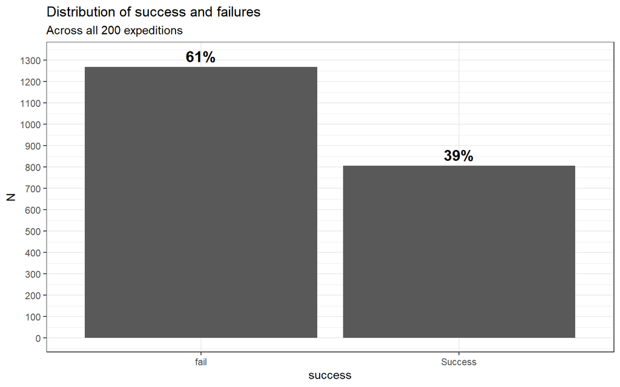

```r
climbers %>%
  mutate(success = ifelse(success == 1, "Success", "fail")) %>%
  count(success) %>%
  mutate(percentage = n/sum(n)) %>%
  ggplot(aes(success, n,
             label = scales::percent(percentage))) +
  geom_bar(stat= "identity") +
  geom_col(width=0.5) +
  geom_text(nudge_y= 50,
            color="black",
            size = 5,
            fontface="bold") +
  scale_y_continuous(breaks = seq(0, 1500, 100)) +
  labs(y = "N",
       title = "Distribution of success and failures",
       subtitle = "Across all 200 expeditions") +
  theme_bw()
```

Each expedition is part of a team, so it would be a mistake to ignore this grouping structure. Below we look at the success rate within each expedition

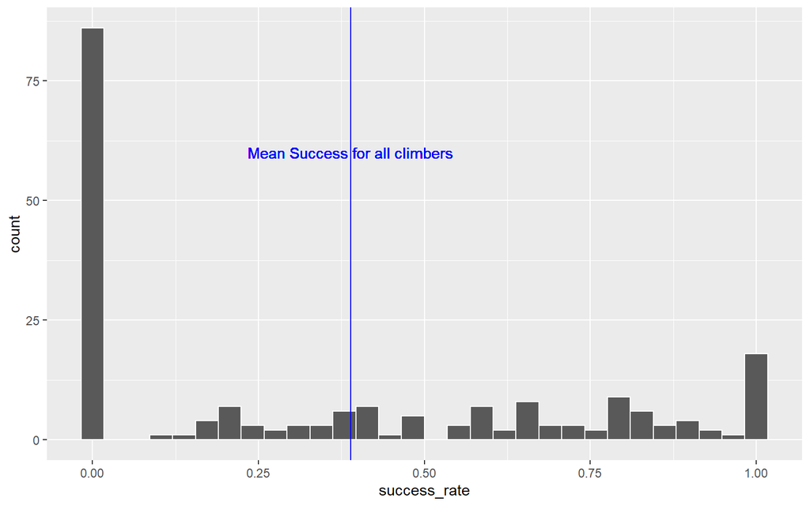

```r
climbers %>%
  group_by(expedition_id) %>%
  summarize(success_rate = mean(success)) %>%
  ggplot(aes(x = success_rate)) +
  geom_histogram(color = "white") +
  geom_vline(xintercept = mean(climbers$success), color = "blue") +
  geom_text(x = mean(climbers$success),
            y = 60,
            label = "Mean Success for all climbers", color = "blue")
```

We can see that there is a good degree of variability across expeditions in terms of the success rate.

We will also look at how some variables affect success rate. Below we look at age and use of oxygen

```r
p1 <- climbers %>%
  ggplot(aes(age)) +
  geom_histogram(aes(y = ..density..)) +
  geom_density()

p2 <- climbers %>%
  mutate(success = ifelse(success == 1, "Success", "fail")) %>%
  ggplot(aes(success , fill = oxygen_used)) +
  geom_bar(stat= 'count', position = 'dodge') +
  labs(x = "Success", y = "Oxygen used during climb",
       title = "Success rate by oxygen use")

p3 <- climbers %>%
  group_by(age, oxygen_used) %>%
  summarize(success_rate = mean(success)) %>%
  ggplot(aes(age, success_rate, color = oxygen_used)) +
  geom_point() +
  geom_smooth(method="lm") +
  labs(title = "Success rate by age and oxygen use",
       y = "Success rate", x = "Age",
       color = "Oxygen Use")
```

[output not shown]

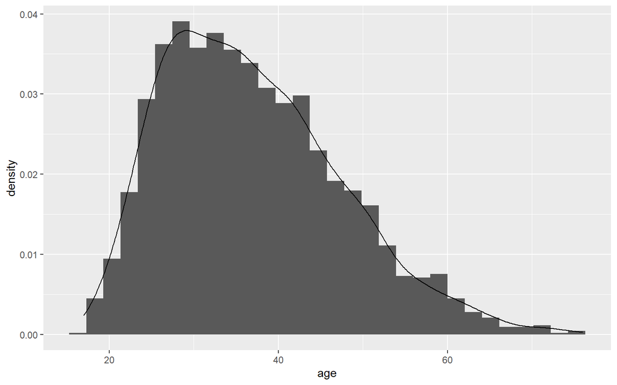

```r
p1
```

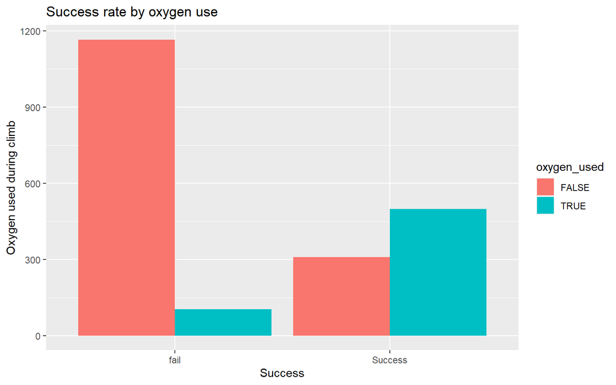

```r
p2
```

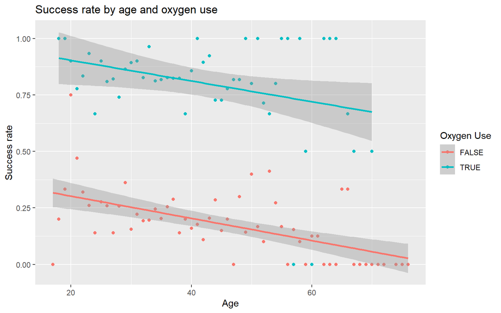

```r
p3
```

The above plots provide evidence that the success rate depends on both age and oxygen use. People who are younger have higher success rates than those who are older, and oxygen use has a much higher success rate, than non oxygen use. It might be fair to think that the effect of both of these variables vary by expedition as well.

### Ignoring grouping structure.

We begin by fitting a model that ignores the grouping structure in the data

```r
log_reg <- glm(success ~ age + oxygen_used, data = climbers,
               family = "binomial")

summary(log_reg)
```

```
##
## Call:
## glm(formula = success ~ age + oxygen_used, family = "binomial",
##     data = climbers)
##
## Deviance Residuals:
##     Min       1Q   Median       3Q      Max
## -2.0353  -0.7115  -0.6198   0.6106   2.0496
##
## Coefficients:
##                 Estimate Std. Error z value Pr(>|z|)
## (Intercept)     -0.51957    0.20733  -2.506   0.0122 *
## age             -0.02197    0.00546  -4.025  5.7e-05 ***
## oxygen_usedTRUE  2.89560    0.12637  22.913  < 2e-16 ***
## ---
## Signif. codes:  0 '***' 0.001 '**' 0.01 '*' 0.05 '.' 0.1 ' ' 1
##
## (Dispersion parameter for binomial family taken to be 1)
##
##     Null deviance: 2774.3  on 2075  degrees of freedom
## Residual deviance: 2048.2  on 2073  degrees of freedom
## AIC: 2054.2
##
## Number of Fisher Scoring iterations: 4
```

Here, we see that:

- While controlling for oxygen use, each additional year of age is assoicated with a 0.02 decrease in the log odds of success.
- While controlling for age, the use of oxygen is associated with a 2.90 increase in the log odds of success (Odds ratio = 18.09)

### Partial pooling model

Next we fit a partial pooling model for this data. That is we fit the model

$$Pr(y_i = success) =log\Big(\frac{\pi_{ij}}{1 - \pi_{ij}}\Big) = logit^{-1}(\alpha_{i[j]} + \beta_1 X_{i[j]1} + \beta_2 X_{i[j]2})$$

$$\alpha_j \sim N(\alpha_\mu, \sigma_\alpha^2)$$

Before fitting the model, let’s think about the parameters we are estimating

- The expedition specific intercepts ($\alpha_j$) tell us the underlying success rates for each expedition $j = 1, \ldots, 200$. This allows some expeditions to be more or less successful than others.
- We are assuming that the intercepts are normally distributed with mean $\alpha_\mu$ and sd $\sigma_\alpha$. These parameters will be estimated from the data.
- $\beta_1$ is the fixed effect of age across all expeditions.
- $\beta_2$ is the fixed effect of oxygen use across all expeditions.

```r
mlm_reg <- glmer(success ~ age + oxygen_used + (1|expedition_id), data = climbers,
               family = "binomial")

summary(mlm_reg)
```

```
## Generalized linear mixed model fit by maximum likelihood (Laplace
##   Approximation) [glmerMod]
##  Family: binomial  ( logit )
## Formula: success ~ age + oxygen_used + (1 | expedition_id)
##    Data: climbers
##
##      AIC      BIC   logLik deviance df.resid
##   1319.7   1342.2   -655.8   1311.7     2072
##
## Scaled residuals:
##      Min       1Q   Median       3Q      Max
## -25.8202  -0.1181  -0.0718   0.1950   3.7836
##
## Random effects:
##  Groups        Name        Variance Std.Dev.
##  expedition_id (Intercept) 13.8     3.715
## Number of obs: 2076, groups:  expedition_id, 200
##
## Fixed effects:
##                 Estimate Std. Error z value Pr(>|z|)
## (Intercept)     -1.77332    0.52298  -3.391 0.000697 ***
## age             -0.04752    0.00921  -5.159 2.48e-07 ***
## oxygen_usedTRUE  6.14595    0.55098  11.155  < 2e-16 ***
## ---
## Signif. codes:  0 '***' 0.001 '**' 0.01 '*' 0.05 '.' 0.1 ' ' 1
##
## Correlation of Fixed Effects:
##             (Intr) age
## age         -0.600
## oxygn_sTRUE -0.428 -0.053
```

Interpretation:

```r
ICC_calc <- (3.715^2)/(3.715^2 + (pi^2/3))
```

We have evidence that much of the variance is explained by differences between expeditions, which is unsurprising.

#### Predictions for a new expedition

Let’s generate predictions for a new expedition in two ways

- Using the predict method
- Using the simulate method.

Here we will create 4 hypothetical new climbers on a new expedition

- Climber 1 is 25 years old and does not use oxygen
- Climber 2 is 25 years old and uses oxygen
- Climber 3 is 55 years old and does not use oxygen
- Climber 4 is 55 years old and uses oxygen

```r
new_expedition<- tribble(
  ~ "age", ~ "oxygen_used", ~ "expedition_id",
  25, FALSE, "new",
  25, TRUE, "new",
  55, FALSE, "new",
  55, TRUE, "new"
)

# log odds scale
predict(mlm_reg, newdata = new_expedition, allow.new.levels = T)
```

```
##         1         2         3         4
## -2.961234  3.184720 -4.386734  1.759220
```

```r
# probability scale
predict(mlm_reg, newdata = new_expedition, allow.new.levels = T,
        type = "response")
```

```
##          1          2          3          4
## 0.04920826 0.96025519 0.01228842 0.85311192
```

Now lets use simulation to predict a new expedition. In class and in assignments I have had you write your own simulation function, but there is in fact a simulation function that comes from the `lme4` package. We can pass new data to get simulations for a new expedition.

```r
new_expedition<- tribble(
  ~ "age", ~ "oxygen_used", ~ "expedition_id",
  25, FALSE, "new",
  25, TRUE, "new",
  55, FALSE, "new",
  55, TRUE, "new"
)

# simulate 250 times
sims <- simulate(mlm_reg,
                 newdata = new_expedition,
                 allow.new.levels = T,
                 nsim = 1000)

apply(sims, 1, function(x) {
  sum(x/length(x))
})
```

```
##     1     2     3     4
## 0.247 0.783 0.159 0.674
```

Well, these estimates look wildly different from those using the `predict()` method. What is going on?

Well the `predict()` function using the fixed effects only to generate a new prediction for each climber. The simulate function is non-deterministic. It begins by sampling random effect values for each expedition, since we have uncertainty in what those might be for a new expedition, and then we use the fixed effects to generate a probability of success.

We can mimic the predict method in the simulate method by setting `re.form=NULL`.

```r
new_expedition<- tribble(
  ~ "age", ~ "oxygen_used", ~ "expedition_id",
  25, FALSE, "new",
  25, TRUE, "new",
  55, FALSE, "new",
  55, TRUE, "new"
)

# simulate 250 times
sims <- simulate(mlm_reg,
                 newdata = new_expedition,
                 re.form = NULL, # don't use random effects
                 allow.new.levels = T,
                 nsim = 1000)

apply(sims, 1, function(x) {
  sum(x/length(x))
})
```

```
##     1     2     3     4
## 0.055 0.962 0.008 0.853
```

This numbers are closer to the predict numbers.

## More than one level of variation

It might be fair to assume that there will be a further cause for variation, which is the mountain peak that is being climbed. Below we plot success rates by expedition and peak

Each point in the plot below is the success rate of an expedition within a peak. The blue dots are the success rates for each peak. Some peaks seem to have higher or lower success rates than others which is not surprising.

[figure not shown]

```r
peak_success <- climbers %>%
  group_by(peak_name) %>%
  summarize(peak_success_rate = sum(success)/n())
climbers %>%
  group_by(peak_name, expedition_id) %>%
  summarize(n_success = sum(success),
            n_fail = sum(success == 0),
            success_rate = n_success/n()) %>%
  left_join(peak_success, by = 'peak_name') %>%
  mutate(peak_expedition = paste(peak_name, expedition_id)) %>%
  ggplot(aes(peak_expedition, success_rate)) +
    geom_jitter() +
  geom_point(aes(peak_expedition, peak_success_rate), color = "blue") +
  coord_flip()
```

We can instead fit the following model:

$$\log\Big(\frac{\pi_{ijk}}{1 - \pi_{ijk}}\Big) = \alpha_{0{jk}} + \beta_1 X_{ijk1} + \beta_2 X_{ijk2}$$

- Where i indexes the climber, j indexes the expedition, and k indexes the mountain peak

and

$$\alpha_{0{jk}} = \alpha_0 + e_{0j} + p_{0k}$$

- Where $\alpha_0$ is a grand intercept
- $e_{0j}$ are deviances by expedition
- $p_{0k}$ are deviances by peak

We further assume that

- $e_{0j} \sim N(0, \sigma_e^2)$
- $p_{0j} \sim N(0, \sigma_p^2)$
- $\sigma_e^2$ is the variability in success rates from expedition to expedition within a peak
- $\sigma_p^2$ is the variability in success rates between peaks

There are two equivalent ways to specify this model using R.

```r
mlm_reg_2_a <- glmer(success ~ age + oxygen_used + (1|peak_id/expedition_id), data = climbers,
               family = "binomial")

mlm_reg_2_b <- glmer(success ~ age + oxygen_used + (1|peak_id) +
                       (1|expedition_id:peak_id), data = climbers,
               family = "binomial")
```

You can explore these models on your own to see that they do in fact give the same results.

Let’s have a look at the estimates from this model. We will use summary as always, but we can also use the broom.mixed package to extract fixed or random effects from the model.

```r
# using summary
summary(mlm_reg_2_a)
```

```
## Generalized linear mixed model fit by maximum likelihood (Laplace
##   Approximation) [glmerMod]
##  Family: binomial  ( logit )
## Formula: success ~ age + oxygen_used + (1 | peak_id/expedition_id)
##    Data: climbers
##
##      AIC      BIC   logLik deviance df.resid
##   1305.8   1334.0   -647.9   1295.8     2071
##
## Scaled residuals:
##      Min       1Q   Median       3Q      Max
## -28.6823  -0.1383  -0.0704   0.2005   3.8161
##
## Random effects:
##  Groups                Name        Variance Std.Dev.
##  expedition_id:peak_id (Intercept) 9.814    3.133
##  peak_id               (Intercept) 2.630    1.622
## Number of obs: 2076, groups:  expedition_id:peak_id, 200; peak_id, 46
##
## Fixed effects:
##                  Estimate Std. Error z value Pr(>|z|)
## (Intercept)     -1.874791   0.612525  -3.061  0.00221 **
## age             -0.047451   0.009153  -5.184 2.17e-07 ***
## oxygen_usedTRUE  6.398651   0.570277  11.220  < 2e-16 ***
## ---
## Signif. codes:  0 '***' 0.001 '**' 0.01 '*' 0.05 '.' 0.1 ' ' 1
##
## Correlation of Fixed Effects:
##             (Intr) age
## age         -0.492
## oxygn_sTRUE -0.242 -0.044
```

```r
# using tidy from broom.mixed
broom.mixed::tidy(mlm_reg_2_a, effects = 'fixed')
```

```
## # A tibble: 3 x 6
##   effect term            estimate std.error statistic  p.value
##   <chr>  <chr>              <dbl>     <dbl>     <dbl>    <dbl>
## 1 fixed  (Intercept)      -1.87     0.613       -3.06 2.21e- 3
## 2 fixed  age              -0.0475   0.00915     -5.18 2.17e- 7
## 3 fixed  oxygen_usedTRUE   6.40     0.570       11.2  3.24e-29
```

Let’s look at the variability estimates between the two models we have fit so far

```r
m1  <- broom.mixed::tidy(mlm_reg, effects = 'ran_pars')
m2 <- broom.mixed::tidy(mlm_reg_2_a, effects = 'ran_pars')

m1
```

```
## # A tibble: 1 x 4
##   effect   group         term            estimate
##   <chr>    <chr>         <chr>              <dbl>
## 1 ran_pars expedition_id sd__(Intercept)     3.72
```

```r
m2
```

```
## # A tibble: 2 x 4
##   effect   group                 term            estimate
##   <chr>    <chr>                 <chr>              <dbl>
## 1 ran_pars expedition_id:peak_id sd__(Intercept)     3.13
## 2 ran_pars peak_id               sd__(Intercept)     1.62
```

What can we say about our models:

We can extract the group level estimates of $e_{0j}$ and $p_{0k}$ using either ranef from the lme4 package or we can use tidy from the broom.mixed package as follows

```r
group_estimates <- broom.mixed::tidy(mlm_reg_2_a, effects = "ran_vals") %>%
    select(level, group, estimate)

head(group_estimates)
```

```
## # A tibble: 6 x 3
##   level          group                 estimate
##   <chr>          <chr>                    <dbl>
## 1 AMAD03107:AMAD expedition_id:peak_id   0.0781
## 2 AMAD03327:AMAD expedition_id:peak_id   2.86
## 3 AMAD05338:AMAD expedition_id:peak_id   1.34
## 4 AMAD06110:AMAD expedition_id:peak_id  -2.49
## 5 AMAD06334:AMAD expedition_id:peak_id  -3.27
## 6 AMAD07101:AMAD expedition_id:peak_id  -3.13
```

We can look at the first two estimates of the peak level estimates

```r
group_estimates %>%
  filter(group == "peak_id") %>%
  head(2)
```

```
## # A tibble: 2 x 3
##   level group   estimate
##   <chr> <chr>      <dbl>
## 1 AMAD  peak_id    3.23
## 2 ANN1  peak_id   -0.999
```

We see that peak_id = “AMAD” (i.e. Ama Dablam) has a higher baseline success rate than peak_id = “ANN1” (i.e. Annapurna I).

Let’s look at some expeditions within AMAD (Ama Dablam.)

```r
climbers %>%
  filter(peak_id == "AMAD") %>%
  distinct(expedition_id)
```

```
## # A tibble: 27 x 1
##    expedition_id
##    <chr>
##  1 AMAD81101
##  2 AMAD84401
##  3 AMAD89102
##  4 AMAD93304
##  5 AMAD98311
##  6 AMAD98316
##  7 AMAD98402
##  8 AMAD03107
##  9 AMAD03327
## 10 AMAD05338
## # ... with 17 more rows
```

```r
# trying a couple at random
group_estimates %>%
  filter(level %in% c("AMAD81101", "AMAD05338"))
```

```
## # A tibble: 0 x 3
## # ... with 3 variables: level <chr>, group <chr>, estimate <dbl>
```

$$\alpha_{0{jk}} = \alpha_0 + e_{0j} + p_{0k}$$

Here are a few questions and exercises to think about.

- If a climber joins a new expedition to AMAD, what is their estimated intercept? Write out these equations using the notation above
- If climbers join a new expedition to a peak not seen in our data, what is their estimated intercept? Write out these equations using the notation above
- Try adding in group level predictors to see if you can improve the estimated intercepts in this model.